# HW4

HW4 for Haoyan

Haoyan Xiang  
2022-01-08

## Halloween Candy Project - HW4

```r
knitr::opts_chunk$set(echo = TRUE)
setwd("~/Downloads")
library(ggplot2)
library(dplyr)
candy = read.csv("candy-data.csv")
head(candy)
```

```
  competitorname chocolate fruity caramel peanutyalmondy nougat
1      100 Grand         1      0       1              0      0
2   3 Musketeers         1      0       0              0      1
3       One dime         0      0       0              0      0
4    One quarter         0      0       0              0      0
5      Air Heads         0      1       0              0      0
6     Almond Joy         1      0       0              1      0
  crispedricewafer hard bar pluribus sugarpercent pricepercent
1                1    0   1        0        0.732        0.860
2                0    0   1        0        0.604        0.511
3                0    0   0        0        0.011        0.116
4                0    0   0        0        0.011        0.511
5                0    0   0        0        0.906        0.511
6                0    0   1        0        0.465        0.767
  winpercent
1   66.97173
2   67.60294
3   32.26109
4   46.11650
5   52.34146
6   50.34755
```

Getting the statistics (mean,median, and sd) of numerical features.

```r
knitr::opts_chunk$set(echo = TRUE)
summarize(candy, mean.sugar = 100*mean(`sugarpercent`), mean.price = 100*mean(`pricepercent`),mean.win = mean(`winpercent`))
```

```
  mean.sugar mean.price mean.win
1   47.86471   46.88824 50.31676
```

```r
knitr::opts_chunk$set(echo = TRUE)
summarize(candy, median.sugar = 100*median(`sugarpercent`), median.price = 100*median(`pricepercent`),median.win = median(`winpercent`))
```

```
  median.sugar median.price median.win
1         46.5         46.5   47.82975
```

```r
knitr::opts_chunk$set(echo = TRUE)
summarize(candy, sd.sugar = 100*sd(`sugarpercent`), sd.price = 100*sd(`pricepercent`),sd.win = sd(`winpercent`))
```

```
  sd.sugar sd.price   sd.win
1 28.27779 28.57396 14.71436
```

We can see from below that chocolate flavored candies are much more welcomed than those without chocolate.

```r
knitr::opts_chunk$set(echo = TRUE)
candy %>%
  group_by(chocolate) %>%
  select('winpercent') %>%
  summarize_all(median, na.rm = TRUE)
```

```
# A tibble: 2 × 2
  chocolate winpercent
      <int>      <dbl>
1         0       41.6
2         1       60.8
```

### Histrogram

**- What questions are left unanswered with your visualizations**  
As this histrogram only tells you about the distribution of pricepercent, it does not tell you the distribution of the other numerical variables such as winpercent.  
**- What about the visualizations may be unclear to a naive viewer**  
In my opinion, this visualization does not require any domain knowledge therefore could be easily understood by any audience. Please note that I assume the readers will read through the definition of each variables before looking at the plot.  
**- How could you improve the visualizations for the final project**  
If I were to use this visualization for the final project, I would change the bin width as there are blanks/gaps in the histogram.

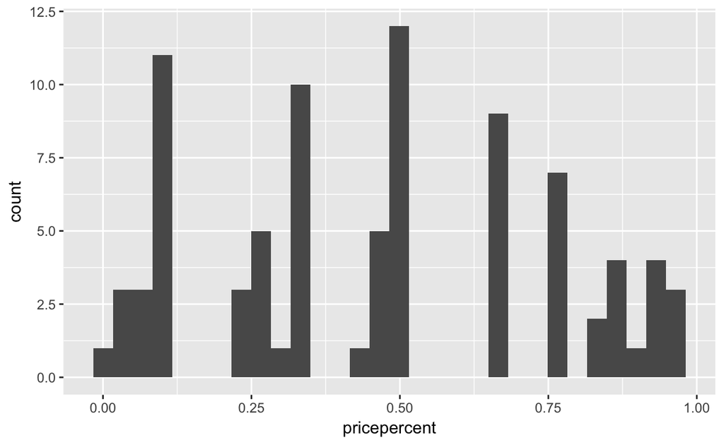

```r
knitr::opts_chunk$set(echo = TRUE)
ggplot(candy, aes(pricepercent)) +
  geom_histogram()
```

### Scatterplot

**- What variable(s) you are visualizing**  
For the scatterplot, the variabls used are sugarpercent and winpercent.

**- What question(s) you are attempting to answer with the visualization**  
This graph can help us understand the relationship between sugar and popularity for the candies.  
**- What conclusions you can make from the visualization**  
We can tell from the graph below that there is no clear relationship between sugar and popularity. In other words, a sweeter candy does not indicate it is more welcomed.

**- What questions are left unanswered with your visualizations**  
We could look at other variables such as hard, which is a binary variable where 1 indicates it is a hard candy and 0 means it is a soft candy, and see if there is a relationship between hard and winpercent.  
**- What about the visualizations may be unclear to a naive viewer**  
In my opinion, this visualization does not require any domain knowledge therefore could be easily understood by any audience.  
**- How could you improve the visualizations for the final project**  
If I were to use this visualization for the final project, I would add a title and a fitted line to it.

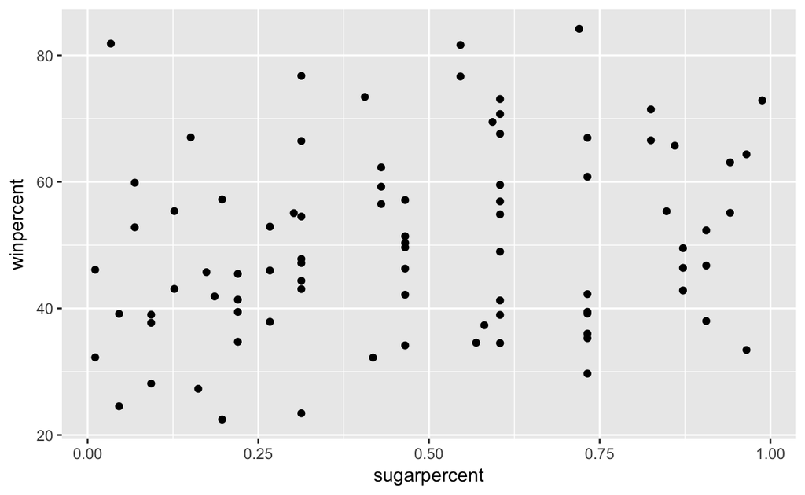

```r
knitr::opts_chunk$set(echo = TRUE)
ggplot(candy, aes(sugarpercent, winpercent)) + geom_point()
```